# Interpreting Binary and Multivariate Regression Models

Dummy Variables, Interaction Effects, and Holding Other Factors Constant

Bogdan G. Popescu

bogdan.popescu@johncabot.edu

John Cabot University

## Table of Contents

1. Regression with Binary Independent Variables
2. Interaction Effects
3. Multivariate Regression

## Regression on a Binary Independent Variable

So far, we only focused on the case where the independent variable is continuous (e.g., urbanization measured as a percent).

We can also apply a similar procedure when **X is binary** (i.e., a dummy variable where X takes two values: 0 and 1).

Our original equation:

$$y = \beta_0 + \beta_1 x + \epsilon$$

Can now be written in the following way for the two cases:

$$E(y|x=0) = \beta_0 + \beta_1 \cdot 0 + \epsilon$$

$$E(y|x=1) = \beta_0 + \beta_1 \cdot 1 + \epsilon$$

## Regression on a Binary Independent Variable

$$E(y|x=0) = \beta_0 + \beta_1 \cdot 0 + \epsilon$$

$$E(y|x=1) = \beta_0 + \beta_1 \cdot 1 + \epsilon$$

Where:

- $E(y|x=0)$ is the expected value of $y$ when $x = 0$
- $E(y|x=1)$ is the expected value of $y$ when $x = 1$

## Regression on a Binary Explanatory Variable

This means:

$$E(y|x=0) = \beta_0 + \beta_1 \cdot 0 + \epsilon$$

$$E(y|x=0) = \beta_0 + \epsilon$$

$$E(y|x=1) = \beta_0 + \beta_1 \cdot 1 + \epsilon$$

$$E(y|x=1) = \beta_0 + \beta_1 + \epsilon$$

So the **only difference** between the two equations is $\beta_1$:

$$E(y|x=0) = \beta_0 + \epsilon \\
E(y|x=1) = \beta_0 + \beta_1 + \epsilon$$

This means that we can write:

$$\beta_1 = E(y|x=1) - E(y|x=0)$$

## Regression on a Binary Explanatory Variable

We can interpret $\beta_1$ as the **difference in the average value of $y$** between the subpopulations where $x = 1$ and $x = 0$.

$\beta_1$ can be **descriptive** or represent the **causal effect** of an intervention or program (if assumptions hold).

For example, to see if EU countries have a higher life expectancy:

$$\beta_1 = E(y|x=1) - E(y|x=0)$$

$$\beta_1 = E(\text{life expectancy} \mid \text{EU}=1) - E(\text{life expectancy} \mid \text{EU}=0)$$

```r
library(dplyr)
library(ggplot2)
setwd("/Users/bgpopescu/Library/CloudStorage/Dropbox/john_cabot/teaching/research_workshop/lecture10/data/")

life_expectancy_df <- read.csv(file = './life-expectancy.csv')
urbanization_df <- read.csv(file = './share-of-population-urban.csv')

urbanization_df2<-urbanization_df%>%
  dplyr::group_by(Entity, Code)%>%
  dplyr::summarize(urb_mean=mean(Urban.population....of.total.population.))

life_expectancy_df2<-life_expectancy_df%>%
  dplyr::group_by(Entity, Code)%>%
  dplyr::summarize(life_expectancy=mean(Life.expectancy.at.birth..historical.))

weird_labels <- c("OWID_KOS", "OWID_WRL", "")
clean_life_expectancy_df<-subset(life_expectancy_df2, !(Code %in% weird_labels))

weird_labels <- c("OWID_KOS", "OWID_WRL", "")
clean_urbanization_df<-subset(urbanization_df2, !(Code %in% weird_labels))

clean_urbanization_df<-subset(clean_urbanization_df, select = -c(Entity))
merged_data<-left_join(clean_life_expectancy_df, clean_urbanization_df, by = c("Code"="Code"))
merged_data2<-na.omit(merged_data)


library("modelsummary")
##############################
#Step4: Labeling EU countries#
##############################
eu_countries <- c(
  "Austria", "Belgium", "Bulgaria", "Croatia", "Cyprus", "Czechia", "Denmark",
  "Estonia", "Finland", "France", "Germany", "Greece", "Hungary", "Ireland",
  "Italy", "Latvia", "Lithuania", "Luxembourg", "Malta", "Netherlands",
  "Poland", "Portugal", "Romania", "Slovakia", "Slovenia", "Spain", "Sweden"
)

model<-lm(life_expectancy~urb_mean, data=merged_data2)

merged_data2$eu<-0
merged_data2$eu[merged_data2$Entity %in% eu_countries] <- 1
merged_data2$eu[is.na(merged_data2$eu)]<-0

x2<-lm(life_expectancy~eu, data=merged_data2)

cm <- c("(Intercept)"="Intercept",
        'eu'='EU')

modelsummary(x2, stars = TRUE, coef_map = cm, gof_map = c("nobs", "r.squared"))
```

|  | (1) |
| --- | --- |
| Intercept | 60.426*** |
|  | (0.614) |
| EU | 6.688*** |
|  | (1.728) |
| Num.Obs. | 214 |
| R2 | 0.066 |

+ p < 0.1, * p < 0.05, ** p < 0.01, *** p < 0.001

## Regression on a Binary Explanatory Variable

We can interpret $\beta_1$ as the **difference in the average value of $y$** between the subpopulations where $x = 1$ and $x = 0$.

$\beta_1$ can be **descriptive** or represent the **causal effect** of an intervention or program (if assumptions hold).

For example, to see if EU countries have a higher life expectancy:

$$\beta_1 = E(y|x=1) - E(y|x=0)$$

$$\beta_1 = E(\text{life expectancy} \mid \text{EU}=1) - E(\text{life expectancy} \mid \text{EU}=0)$$

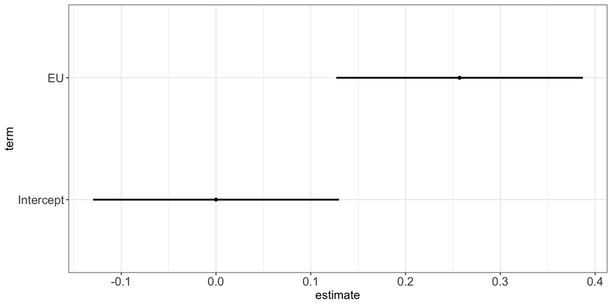

```r
library(broom)
model_scaled<-lm(scale(life_expectancy)~scale(eu), data=merged_data2)
results<-tidy(model_scaled)

cm <- c('scale(eu)'='EU',
        "(Intercept)"="Intercept")

ggplot(results, aes(x = estimate, y = term)) +
      geom_point()+
      geom_errorbar(aes(xmin = estimate-1.96*std.error,
                        xmax = estimate+1.96*std.error),
                linewidth = 1, width=0)+
  scale_y_discrete(labels = cm) +  # this maps term names to nicer labels
  theme_bw()+
   theme(
    axis.text  = element_text(size = 14),
    axis.title = element_text(size = 14),
    plot.title = element_text(hjust = 0.5))
```

## Regression on a Binary Explanatory Variable

We can interpret $\beta_1$ as the **difference in the average value of $y$** between the subpopulations where $x = 1$ and $x = 0$.

$\beta_1$ can be **descriptive** or represent the **causal effect** of an intervention or program (if assumptions hold).

For example, to see if EU countries have a higher life expectancy:

$$\beta_1 = E(y|x=1) - E(y|x=0)$$

$$\beta_1 = E(\text{life expectancy} \mid \text{EU}=1) - E(\text{life expectancy} \mid \text{EU}=0)$$

$\beta_1$ = 67.114 − 60.426  
$\beta_1$ = 6.688

## Group Means: Life Expectancy in EU vs. Non-EU Countries

Before running a regression, let’s look at the average life expectancy in each group:

| EU | mean_life_expectancy | n |
| --- | --- | --- |
| EU | 67.11 | 27 |
| Non-EU | 60.43 | 187 |

This helps us see what the regression is about to estimate.

We’ll expect the regression slope $\beta_1$ to be roughly:

$$\text{Mean}_{EU} - \text{Mean}_{Non-EU}$$

## Regression on a Binary Explanatory Variable

The interpretation of $\beta_1$:

- EU countries have 6.6 more years of life compared with non-EU countries in the sample.
- Better said: life expectancy is 6.6 years higher in the EU, compared to non-EU countries.
- This difference is significant at a 0.1% significance level (0.001*100=0.1).
- EU countries live 6.688 + 60.426 = 67.114 years

## Interaction Effects

What if we interacted urbanization with some of our other variables?

$$\begin{align*}
y &= \beta_0 + \beta_1 x_1 + \beta_2 x_2 + \beta_3 x_3 + \epsilon \\
\text{life expectancy} &= \beta_0 + \beta_1 \cdot \text{EU} + \beta_2 \cdot \text{urbanization} + \beta_3 \cdot (\text{EU} \times \text{urbanization}) + \epsilon
\end{align*}$$

```r
merged_data2$eu_urbanization<-merged_data2$eu*merged_data2$urb_mean
x3<-lm(life_expectancy~eu+urb_mean + eu_urbanization, data=merged_data2)

cm <- c("(Intercept)"="Intercept",
        'eu'='EU',
        "urb_mean" = "Urbanization",
        "eu_urbanization"="EU * Urbanization")

modelsummary(x3, stars = TRUE, coef_map = cm, gof_map = c("nobs", "r.squared"))
```

|  | (1) |
| --- | --- |
| Intercept | 48.981*** |
|  | (1.044) |
| EU | 33.095*** |
|  | (6.611) |
| Urbanization | 0.233*** |
|  | (0.019) |
| EU * Urbanization | -0.456*** |
|  | (0.097) |
| Num.Obs. | 214 |
| R2 | 0.464 |

+ p < 0.1, * p < 0.05, ** p < 0.01, *** p < 0.001

## Interaction Effects

What if we interacted urbanization with some of our other variables?

|  | (1) |
| --- | --- |
| Intercept | 48.981*** |
|  | (1.044) |
| EU | 33.095*** |
|  | (6.611) |
| Urbanization | 0.233*** |
|  | (0.019) |
| EU * Urbanization | -0.456*** |
|  | (0.097) |
| Num.Obs. | 214 |
| R2 | 0.464 |

+ p < 0.1, * p < 0.05, ** p < 0.01, *** p < 0.001

## Interaction Effects

What if we interacted urbanization with some of our other variables?

|  | (1) |
| --- | --- |
| Intercept | 48.981*** |
|  | (1.044) |
| EU | 33.095*** |
|  | (6.611) |
| Urbanization | 0.233*** |
|  | (0.019) |
| EU * Urbanization | -0.456*** |
|  | (0.097) |
| Num.Obs. | 214 |
| R2 | 0.464 |

+ p < 0.1, * p < 0.05, ** p < 0.01, *** p < 0.001

## Interaction Effects

What if we interacted urbanization with some of our other variables?

|  | (1) |
| --- | --- |
| Intercept | 48.981*** |
|  | (1.044) |
| EU | 33.095*** |
|  | (6.611) |
| Urbanization | 0.233*** |
|  | (0.019) |
| EU * Urbanization | -0.456*** |
|  | (0.097) |
| Num.Obs. | 214 |
| R2 | 0.464 |

+ p < 0.1, * p < 0.05, ** p < 0.01, *** p < 0.001

Since the slope for urbanization for the rest of the world is 0.233, it means that on average, a one-unit increase in urbanization in any country *outside* the EU leads to an increase in life expectancy of 0.233 years.

In the EU, by contrast, a one-unit increase in urbanization is associated with a decrease in life expectancy of -0.223 years.

## Interaction Effects

```r
# Step 1: Label EU countries
eu_countries <- c(
  "Austria", "Belgium", "Bulgaria", "Croatia", "Cyprus", "Czechia", "Denmark",
  "Estonia", "Finland", "France", "Germany", "Greece", "Hungary", "Ireland",
  "Italy", "Latvia", "Lithuania", "Luxembourg", "Malta", "Netherlands",
  "Poland", "Portugal", "Romania", "Slovakia", "Slovenia", "Spain", "Sweden"
)

merged_data2$eu <- ifelse(merged_data2$Entity %in% eu_countries, 1, 0)
merged_data2$type <- ifelse(merged_data2$Entity %in% eu_countries, "EU", "Everything Else")

# Step 2: Fit interaction model
merged_data2$eu_urbanization <- merged_data2$eu * merged_data2$urb_mean
model <- lm(life_expectancy ~ urb_mean + eu + eu_urbanization, data = merged_data2)

# Step 3: Extract coefficients
b0 <- coef(model)["(Intercept)"]
b1 <- coef(model)["urb_mean"]
b2 <- coef(model)["eu"]
b3 <- coef(model)["eu_urbanization"]

# Step 4: Compute lines
x_vals <- c(0, 100)
non_eu_line <- data.frame(
  x = x_vals,
  y = b0 + b1 * x_vals,
  group = "Everything Else"
)

eu_line <- data.frame(
  x = x_vals,
  y = (b0 + b2) + (b1 + b3) * x_vals,
  group = "EU"
)

regression_lines <- rbind(non_eu_line, eu_line)

# Step 5: Plot
cols <- c("Everything Else" = "black", "EU" = "blue")
shapes <- c("Everything Else" = 16, "EU" = 3)

ggplot(merged_data2) +
    geom_point(data = merged_data2, aes(x = urb_mean, y = life_expectancy, color = type, shape = type), size=2)+
  geom_line(data = regression_lines, aes(x = x, y = y, color = group, group = group),
            linetype = "solid", size = 1, inherit.aes = FALSE)+
  scale_shape_manual(name = "", values = shapes) +
  scale_color_manual(name = "", values = cols) +

  scale_x_continuous(name = "Urbanization", breaks = seq(0, 100, 20), limits = c(0, 100)) +
  scale_y_continuous(name = "Life Expectancy", breaks = seq(0, 100, 20), limits = c(0, 100)) +
  theme_bw() +
theme(
  axis.text.x = element_text(size = 14),
  axis.title = element_text(size = 14),
  plot.title = element_text(hjust = 0.5),
  legend.position = "bottom",  # Or "right", "top"
  legend.title = element_blank(),
  legend.box.background = element_rect(fill = 'white'),
  legend.background = element_blank(),
  legend.text = element_text(size = 12)
)
```

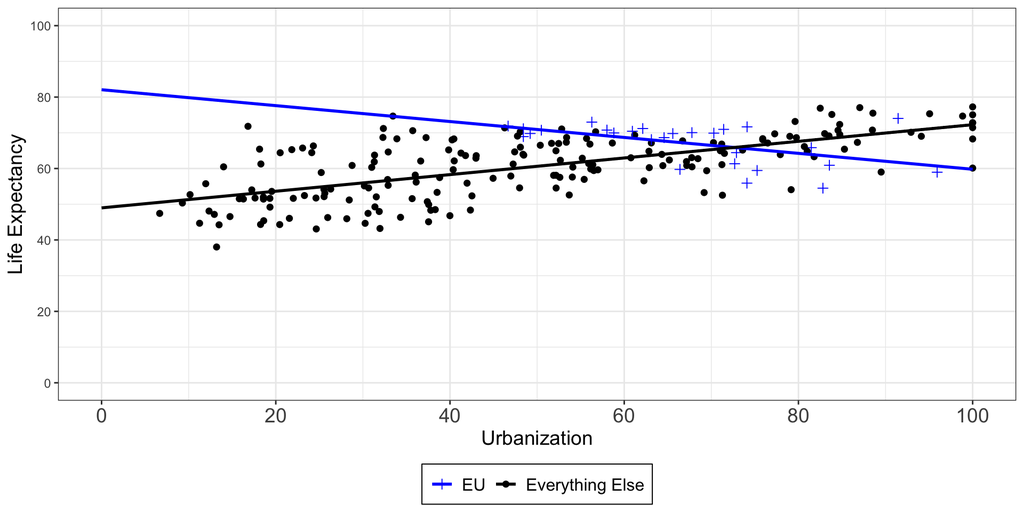

## Interaction Effects

```r
# Step 1: Label EU countries
eu_countries <- c(
  "Austria", "Belgium", "Bulgaria", "Croatia", "Cyprus", "Czechia", "Denmark",
  "Estonia", "Finland", "France", "Germany", "Greece", "Hungary", "Ireland",
  "Italy", "Latvia", "Lithuania", "Luxembourg", "Malta", "Netherlands",
  "Poland", "Portugal", "Romania", "Slovakia", "Slovenia", "Spain", "Sweden"
)

merged_data2$eu <- ifelse(merged_data2$Entity %in% eu_countries, 1, 0)
merged_data2$type <- ifelse(merged_data2$Entity %in% eu_countries, "EU", "Everything Else")

# Step 2: Fit interaction model
merged_data2$eu_urbanization <- merged_data2$eu * merged_data2$urb_mean
model <- lm(life_expectancy ~ urb_mean + eu + eu_urbanization, data = merged_data2)

# Step 3: Extract coefficients
b0 <- coef(model)["(Intercept)"]
b1 <- coef(model)["urb_mean"]
b2 <- coef(model)["eu"]
b3 <- coef(model)["eu_urbanization"]

# Step 4: Compute lines
x_vals <- c(0, 100)
non_eu_line <- data.frame(
  x = x_vals,
  y = b0 + b1 * x_vals,
  group = "Everything Else"
)

eu_line <- data.frame(
  x = x_vals,
  y = (b0 + b2) + (b1 + b3) * x_vals,
  group = "EU"
)

regression_lines <- rbind(non_eu_line, eu_line)

# Step 5: Plot
cols <- c("Everything Else" = "black", "EU" = "blue")
shapes <- c("Everything Else" = 16, "EU" = 3)

ggplot(merged_data2) +
    geom_point(data = merged_data2, aes(x = urb_mean, y = life_expectancy, color = type, shape = type), alpha = .2, size=2)+
  geom_line(data = regression_lines, aes(x = x, y = y, color = group, group = group),
            linetype = "solid", size = 1, alpha = .2, inherit.aes = FALSE)+
  scale_shape_manual(name = "", values = shapes) +
  scale_color_manual(name = "", values = cols) +

  scale_x_continuous(name = "Urbanization", breaks = seq(0, 100, 20), limits = c(0, 100)) +
  scale_y_continuous(name = "Life Expectancy", breaks = seq(0, 100, 20), limits = c(0, 100)) +
  theme_bw() +
    # Slope annotations
  annotate("text", x = 10, y = b0 + b1 * 20 + 5,
           label = paste0("Slope (b) = ", round(b1, 3)),
           color = "black", size = 5) +
  annotate("text", x = 10, y = (b0 + b2) + (b1 + b3) * 20 - 5,
           label = paste0("Slope (b) = ", round(b1 + b3, 3)),
           color = "blue", size = 5) +
theme(
  axis.text.x = element_text(size = 14),
  axis.title = element_text(size = 14),
  plot.title = element_text(hjust = 0.5),
  legend.position = "bottom",  # Or "right", "top"
  legend.title = element_blank(),
  legend.box.background = element_rect(fill = 'white'),
  legend.background = element_blank(),
  legend.text = element_text(size = 12)
)
```

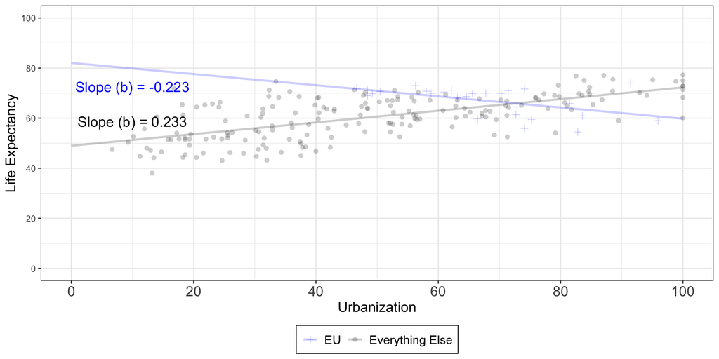

## Interaction Effects

```r
# Step 1: Label EU countries
eu_countries <- c(
  "Austria", "Belgium", "Bulgaria", "Croatia", "Cyprus", "Czechia", "Denmark",
  "Estonia", "Finland", "France", "Germany", "Greece", "Hungary", "Ireland",
  "Italy", "Latvia", "Lithuania", "Luxembourg", "Malta", "Netherlands",
  "Poland", "Portugal", "Romania", "Slovakia", "Slovenia", "Spain", "Sweden"
)

merged_data2$eu <- ifelse(merged_data2$Entity %in% eu_countries, 1, 0)
merged_data2$type <- ifelse(merged_data2$Entity %in% eu_countries, "EU", "Everything Else")

# Step 2: Fit interaction model
merged_data2$eu_urbanization <- merged_data2$eu * merged_data2$urb_mean
model <- lm(life_expectancy ~ urb_mean + eu + eu_urbanization, data = merged_data2)

# Step 3: Extract coefficients
b0 <- coef(model)["(Intercept)"]
b1 <- coef(model)["urb_mean"]
b2 <- coef(model)["eu"]
b3 <- coef(model)["eu_urbanization"]

# Step 4: Compute lines
x_vals <- c(0, 100)
non_eu_line <- data.frame(
  x = x_vals,
  y = b0 + b1 * x_vals,
  group = "Everything Else"
)

eu_line <- data.frame(
  x = x_vals,
  y = (b0 + b2) + (b1 + b3) * x_vals,
  group = "EU"
)

regression_lines <- rbind(non_eu_line, eu_line)

# Step 5: Plot
cols <- c("Everything Else" = "black", "EU" = "blue")
shapes <- c("Everything Else" = 16, "EU" = 3)


ggplot(merged_data2) +
  geom_point(data = merged_data2, aes(x = urb_mean, y = life_expectancy, color = type, shape = type), alpha = .2, size=2)+
  geom_line(data = regression_lines, aes(x = x, y = y, color = group, group = group),
            linetype = "solid", size = 1, alpha = .2, inherit.aes = FALSE)+
  scale_shape_manual(name = "", values = shapes) +
  scale_color_manual(name = "", values = cols) +

  scale_x_continuous(name = "Urbanization", breaks = seq(0, 100, 20), limits = c(0, 100)) +
  scale_y_continuous(name = "Life Expectancy", breaks = seq(0, 100, 20), limits = c(0, 100)) +
  theme_bw() +
  # Intercept annotations
  annotate("point", x = 0, y = b0, color = "black", size = 3) +
  annotate("text", x = 2, y = b0 + 2,
           label = paste0("Intercept (a) = ", round(b0, 2)),
           hjust = 0, color = "black", size = 5) +

  annotate("point", x = 0, y = b0 + b2, color = "blue", size = 3) +
  annotate("text", x = 2, y = b0 + b2 + 2,
           label = paste0("Intercept (a) = ", round(b0 + b2, 2)),
           hjust = 0, color = "blue", size = 5) +

theme(
  axis.text.x = element_text(size = 14),
  axis.title = element_text(size = 14),
  plot.title = element_text(hjust = 0.5),
  legend.position = "bottom",  # Or "right", "top"
  legend.title = element_blank(),
  legend.box.background = element_rect(fill = 'white'),
  legend.background = element_blank(),
  legend.text = element_text(size = 12)
)
```

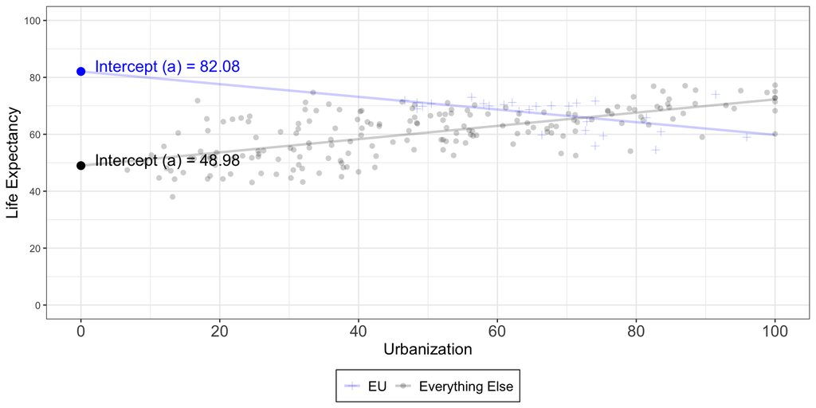

## Interaction Effects

An interaction eﬀect allows us to identify the change that happens when combining two explanatory variables:

- Urbanization eﬀect
- EU eﬀect
- Additional urbanization eﬀect in the EU

## Multivariate Regression

Up until now, we only had one independent variable: urbanization

$$\text{life expectancy} = \beta_0 + \beta_1 \text{urbanization} + \epsilon$$

But many other variables could be explaining life expectancy beyond urbanization

Thus, we need to ask ourselves?

- What characteristics do countries with longer life expectancy have in common?
- What characteristics do countries with shorter life expectancy have in common?
- Normally, we would be examining the relationship between different types of variables and life expectancy:
  - income
  - urbanization
  - education

## Multivariate Regression

## Multivariate Regression

### Specification

We can now run something like:

$$\text{life expectancy} = \beta_0 + \beta_1 \text{urbanization} + \beta_2 \text{GDP} + \epsilon$$

```r
setwd("/Users/bgpopescu/Library/CloudStorage/Dropbox/john_cabot/teaching/research_workshop/lecture10/data/")
gdp <- read.csv(file = './gdp-per-capita-maddison-2020.csv')
gdp2 <- gdp %>%
    group_by(Code) %>%
    summarize(gdp = mean(GDP.per.capita))

# Removing continents
gdp3 <- subset(gdp2, gdp2$Code != "")
merged_data3<-left_join(merged_data2, gdp3, by = c("Code"="Code"))
merged_data3<-na.omit(merged_data3)
#Taking the log
merged_data3$log_gdp<-log(merged_data3$gdp)
```

## Regression Example

### Interpretation

This is how we create a professionally-looking table.

```r
library("modelsummary")
model<-lm(life_expectancy~urb_mean+log_gdp, data=merged_data3)

models<-list("DV: Life Expectancy" = model)

cm <- c('urb_mean'='Urbanization',
        'log_gdp'='GDP',
        "(Intercept)"="Intercept")

modelsummary(models, stars = TRUE, coef_map = cm, gof_map = c("nobs", "r.squared"))
```

|  | DV: Life Expectancy |
| --- | --- |
| Urbanization | 0.054+ |
|  | (0.029) |
| GDP | 5.947*** |
|  | (0.699) |
| Intercept | 7.060 |
|  | (4.880) |
| Num.Obs. | 164 |
| R2 | 0.608 |

+ p < 0.1, * p < 0.05, ** p < 0.01, *** p < 0.001

## Regression Example

### Interpretation

This is how we create a professionally-looking plot

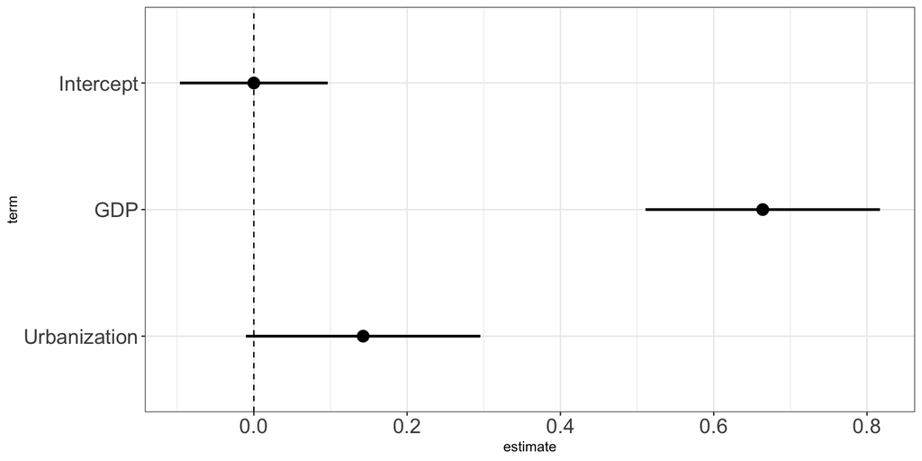

```r
#Step1: To make readable graphs, we need to standardize our coefficients:
# Scaling variables means subtracting the mean of the original variable from the raw value and then divide it by the standard deviation of the original variable.
x5_b<-lm(scale(life_expectancy)~scale(urb_mean)+scale(log_gdp),data=merged_data3)
#Step2: Tyding your coeficients
results1_b <- tidy(x5_b)

cm <- c('scale(urb_mean)'='Urbanization',
        'scale(log_gdp)'='GDP',
        "(Intercept)"="Intercept")

# Ensure the levels of 'term' match the names of cm
results1_b$term <- factor(results1_b$term, levels = names(cm))

graph_results1_b <- ggplot(results1_b,
       aes(x = estimate, y = term)) +
    geom_point(position = position_dodge(width = 0.4), size = 4) +
    geom_errorbar(aes(xmin = estimate - 1.96 * std.error,
                      xmax = estimate + 1.96 * std.error),
                  size = 1, width = 0,
                  position = position_dodge(width = 0.4)) +
    geom_vline(xintercept = 0, color = "black", linetype = "dashed") +
    scale_y_discrete(labels = cm) +
    theme_bw() +
    theme(axis.text.x = element_text(size = 16),
          axis.text.y = element_text(size = 16),
          legend.position = c(1, 0),
          legend.box.background = element_rect(fill = 'white'),
          legend.background = element_blank(),
          legend.text = element_text(size = 16))
graph_results1_b
```

## Regression Example

### Interpretation

We can now interpret the coefficients:

```r
library("modelsummary")
model<-lm(life_expectancy~urb_mean+log_gdp, data=merged_data3)

models<-list("DV: Life Expectancy" = model)

cm <- c('urb_mean'='Urbanization',
        'log_gdp'='GDP',
        "(Intercept)"="Intercept")

modelsummary(models, stars = TRUE, coef_map = cm, gof_map = c("nobs", "r.squared"))
```

|  | DV: Life Expectancy |
| --- | --- |
| Urbanization | 0.054+ |
|  | (0.029) |
| GDP | 5.947*** |
|  | (0.699) |
| Intercept | 7.060 |
|  | (4.880) |
| Num.Obs. | 164 |
| R2 | 0.608 |

+ p < 0.1, * p < 0.05, ** p < 0.01, *** p < 0.001

- Urbanization: Every unit increase in urbanization has a 0.054 increase in life expectancy, *holding everything else constant*
- Log GDP: Every unit increase in log GDP has a 5.947 increase in life expectancy, *holding everything else constant*

## Regression Example

### Interpretation

We can now interpret the coefficients:

```r
library("modelsummary")
model<-lm(life_expectancy~urb_mean+log_gdp, data=merged_data3)

models<-list("DV: Life Expectancy" = model)

cm <- c('urb_mean'='Urbanization',
        'log_gdp'='GDP',
        "(Intercept)"="Intercept")

modelsummary(models, stars = TRUE, coef_map = cm, gof_map = c("nobs", "r.squared"))
```

|  | DV: Life Expectancy |
| --- | --- |
| Urbanization | 0.054+ |
|  | (0.029) |
| GDP | 5.947*** |
|  | (0.699) |
| Intercept | 7.060 |
|  | (4.880) |
| Num.Obs. | 164 |
| R2 | 0.608 |

+ p < 0.1, * p < 0.05, ** p < 0.01, *** p < 0.001

- Note that our independent variable was logged.
- The right interpretation is: A 1% increase in GDP per capita has a 5.947/100 = 0.05947 increase in life expectancy.

## Multivariate Regressions

### R Sq. and Adj. R Sq.

- The output provided by R for multiple regression is exactly the same as for bivariate regression
- Sometimes we need to be conscious that we are talking about more than one predictor variable
- In a multivariate regression, we care about the **adjusted R squared**
- The reason is that the value of the $R^2$ never decreases no matter the number of variables we add to our regression model.
- Even if we are adding redundant variables to the model, the value of R-squared does not decrease.
- In the case of the Adjusted R-squared, adding redundant variables to the model reduces the Adjusted R-squared: the Adjusted R-squared can thus be negative: This usually happens when the model fits the data worse than a model with no predictors — meaning it adds noise rather than explanatory power.

## Conclusion: What You Should Remember

- **Binary regression** estimates **group differences**:
  $$\beta_1 = \text{mean}(y \mid x = 1) - \text{mean}(y \mid x = 0)$$
- Always check **group means** and **sample sizes** first.
- **Interaction terms** allow effects to vary across groups  
  (e.g. slope/intercept differences for EU vs. non-EU).
- **Multivariate regression** controls for other factors:  
  coefficients show the effect of one variable **holding others constant**.
- Use **Adjusted $R^2$** to assess model fit when adding predictors.